# American CDI data

Colin Ayres

2024-11-19

## Data preparation

Import the data from `cdi.csv`:

```r
read.csv("cdi.csv") -> cdi
```

Reshape the data frame to the *long* format gathering responses to each item (word) in a single column called `response` and adding a column identifying items (words) called `item`:

```r
colnames(cdi)[grep("item_", colnames(cdi))] -> words
reshape(cdi, direction = "long", varying = words, v.names = "response", timevar = "item", times = words, idvar = "student") -> long_cdi
```

- `response == "produces"`: the child can say and understand a given word
- `response == "understands"`: the child can only understand a given word

Add a column (logical or 0/1) called `production` coding whether a child can say the word and a column (logical or 0/1) called `comprehension` coding whether a child can understand the word only:

```r
long_cdi$production <- ifelse(long_cdi$response == "produces", 1, 0)
long_cdi$comprehension <- ifelse(long_cdi$response == "understands", 1, 0)
#If either production or comprehension then they can comprehend. "either" column represents comprehension
long_cdi$either <- ifelse(long_cdi$production == 1 | long_cdi$comprehension == 1, 1, 0)
```

*Could we transform the data into even a “longer” format now?*

To make the data longer we need multiple columns which contain the same variable. I can’t make my long_cdi data longer.

Create a new data frame with summed up comprehension scores for each child (and keeping age, sex and parental education):

```r
aggregate(list(summed_comprehension = long_cdi$either), list(age = long_cdi$age, caregiver_education = long_cdi$caregiver_education, sex = long_cdi$sex, student = long_cdi$student), sum) -> cdi_sums
```

**Make sure you haven’t lost any data when performing any of the above transformations** **(reshaping and aggregating in particular).**

I have 3746 rows in my aggregate data frame but 5123 rows in the original data frame. The reason this happened is because of NA columns; subjects with NA in the caregiver_education column weren’t included in the aggregate

## Comprehension by sex and parental education

```r
cdi_sums$caregiver_education <- ifelse(cdi_sums$caregiver_education == "Some Secondary" , "Primary", cdi_sums$caregiver_education)
cdi_sums$caregiver_education <- ifelse(cdi_sums$caregiver_education == "Some College" , "Secondary", cdi_sums$caregiver_education)
cdi_sums$caregiver_education <- ifelse(cdi_sums$caregiver_education == "Some Graduate" , "College", cdi_sums$caregiver_education)
cdi_sums$caregiver_education <- factor(cdi_sums$caregiver_education, levels = c("Primary", "Secondary", "College", "Graduate"))
```

There were 1996 boys and 1750 girls in the sample.

Add a barplot of mean scores by sex and parental education:

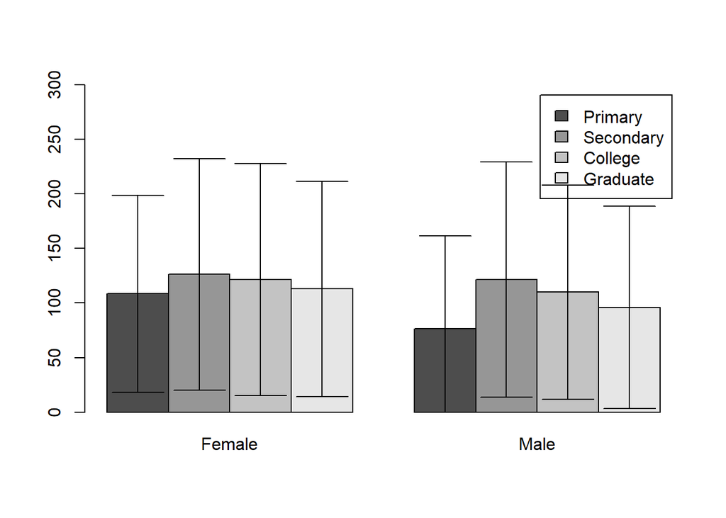

```r
barplot(tapply(cdi_sums$summed_comprehension, list(cdi_sums$caregiver_education, cdi_sums$sex), mean, na.rm = TRUE), beside = TRUE, ylim = c(0, 300), legend = TRUE) -> cdi_plot
#cdi_sums$caregiver_education, cdi_sums$sex
tapply(cdi_sums$summed_comprehension, list(cdi_sums$caregiver_education, cdi_sums$sex), mean, na.rm = TRUE) -> cdimeans
sqrt(tapply(cdi_sums$summed_comprehension, list(cdi_sums$caregiver_education, cdi_sums$sex), var, na.rm = TRUE)) -> cdisds
arrows(x0 = cdi_plot, y0 = cdimeans - cdisds, x1 = cdi_plot, y1 = cdimeans + cdisds, angle = 90, code = 3)
```